# Analyze single cell plasmid data

Jessica has done experiments to measure the number of plasmid spots per cell for a number of plasmids. She provided raw data that I merged into a single excel file called "plasmid_copies_per_cell.xlsx." All variables in this excel file include.

- plasmid: cp26, cp32-3, cp32-4, cp32-7, cp32-8, lp21, lp25, lp28-1, or lp54. cp26 was excluded from this analysis since we are only considering non essential plasmids.
- growth_phase: exponential or stationary phase.
- replicate: 1 or 2. These are biological replicates
- cell_length: cell length in microns
- mean_OriC: mean fluorescence intensity of mCherry signal for the entire cell (OriC signal).
- mean_plasmid: mean fluorescence intensity of GFP signal for the entire cell (plasmid signal).
- oriC_spots: number of observed oriC spots in cells.
- plasmid_spots: number of observed plasmid spots in cells.
- OriC_per_10um: number of observed oriC spots per 10um of cell length. This is just a normalization considering cell length since it can be so variable.
- plasmid_per_10um: number of observed plasmid spots per 10um of cell length. Same as above.
- oriC_spot_intensity: integrated intensity of OriC spots.
- plasmid_spot_intensity: integrated intensity of plasmid spots.
- OriC_spot_cv: coefficient of variation between OriC spots.
- plasmid_spot_cv: coefficient of variation between plasmid spots.
- mean_spot_fluor_density_che: Mean of the OriC spot intensities in the cell.
- mean_spot_fluor_density_gfp: Mean of the plasmid spot intensities in the cell.
- mean_nonspot_fluor_density_che: Mean signal of all pixels outside of spot localizations for OriC channel.
- mean_nonspot_fluor_density_gfp: Mean signal of all pixels outside of spot localizations for plasmid channel.
- mean_spot_nonspot_fluor_density_che: Mean between the spot vs. nonspot measurements of the OriC channel.
- mean_spot_nonspot_fluor_density_gfp: Mean between the spot vs. nonspot measurements of the plasmid channel.

The goal of this analysis is to quantify the following:

1. Mean copies of plasmid content per cell
2. Fraction of cells without each respective plasmid
3. The variance of plasmid retention between growth phases.

Code produced by Joshua W. McCausland in the CJW lab, 2024.

```python
# required pacakge for this script.
import pandas as pd # for making, sorting, and running calculations through dataframes.
from matplotlib import pyplot as plt # plotting.
plt.rcParams['font.family'] = 'Arial' # plotting
import seaborn as sns # plotting.
from scipy import stats # for statistics calculations throughout.

# just to suppress depreciation warnings.
import warnings
warnings.filterwarnings('ignore')

plasmid_to_exclude = 'cp26' # as mentioned in the prelude, we will exclude cp26 since we are only interested in nonessential plasmids.
plasmid_data = pd.read_excel('plasmid_copies_per_cell.xlsx') #load the plasmid copies excel file as a dataframe.
plasmid_data = plasmid_data[~plasmid_data.plasmid.str.contains(plasmid_to_exclude)] # exclude cp26

# Measure the mean of all single cells for each replicate.
mean_df = plasmid_data.groupby(by=['plasmid','growth_phase','replicate']).mean(numeric_only=True).reset_index()

# Count the number of cells for each replicate.
cell_count = plasmid_data.groupby(by=['plasmid','growth_phase','replicate']).size().reset_index().rename(columns={0: 'cell_num'})

# Appent the cell count to the mean dataframe.
mean_df['cell_num'] = cell_count['cell_num']

# Save the mean dataframe for Jessica.
mean_df.to_excel('prepared_plasmid_data_for_Jessica.xlsx')
```

Now that a prepared mean dataframe is ready, my first task is to reproduce what Jessica has before to make sure we are working along the same line. Below I replicate Fig. 4C: the number of observed plasmid spots per plasmid and growth phase condition.

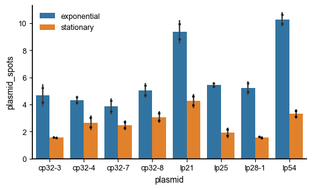

```python
_figsize = [5,3] # size of the figure in inches, w x h.

fig,_ax = plt.subplots(figsize=_figsize,layout='constrained')
sns.barplot(data=mean_df,x='plasmid',y='plasmid_spots',hue='growth_phase',ax=_ax,errwidth=1.7,errorbar='sd')
sns.swarmplot(data=mean_df,x='plasmid',y='plasmid_spots',hue='growth_phase',dodge=True,ax=_ax,color = 'black',size=3,legend=False)
_ax.legend(frameon = False,fontsize=9)
_ax.tick_params(axis='both',labelsize=9)
_ax.spines[['right', 'top']].set_visible(False)
_ax.spines[['left', 'bottom']].set_linewidth(1.2)
```

Next is the fraction of cells with no plasmids for each replicate. This involves a simple counting function to add up the number zeroes in each replicate.

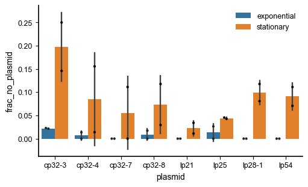

```python
_figsize = [5,3] # size of the figure in inches, w x h.

# count the number of cells with no plasmids in each replicate.
mean_df['num_no_plasmid'] = plasmid_data.groupby(by=['plasmid','growth_phase','replicate']).agg(lambda x: x.eq(0).sum()).reset_index().plasmid_spots
# determine the fraction of cells without plasmids.
mean_df['frac_no_plasmid'] = mean_df.num_no_plasmid / mean_df.cell_num

fig,_ax = plt.subplots(figsize=_figsize,layout='constrained')
sns.barplot(data=mean_df,x='plasmid',y='frac_no_plasmid',hue='growth_phase',ax=_ax,errwidth=1.7,errorbar='sd')
sns.swarmplot(data=mean_df,x='plasmid',y='frac_no_plasmid',hue='growth_phase',dodge=True,ax=_ax,color = 'black',size=3,legend=False)
_ax.legend(frameon = False,fontsize=9)
_ax.tick_params(axis='both',labelsize=9)
_ax.spines[['right', 'top']].set_visible(False)
_ax.spines[['left', 'bottom']].set_linewidth(1.2)
```

I have recapulated Jessica's observations with the above graphs. Now to assess the question at hand. Each plasmid measurement is comprised of two biological replicates. Our central question is whether plasmid copy number in general *decreases* in stationary phase. Here, I will pool all plasmid results and strictly compare growth phases.

```
p value is 0.00448859381939911
```

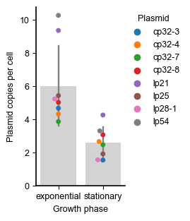

```python
_figsize = [3.3,3] # size of the figure in inches, w x h.

# determine the mean of the two biological replicates for each plasmid in its respective growth phase.
df=mean_df.groupby(by=['plasmid','growth_phase']).mean().reset_index()

fig,_ax = plt.subplots(figsize=_figsize,layout='constrained')
sns.barplot(data=df,x='growth_phase',y='plasmid_spots',color = 'lightgray',errcolor='gray',ax=_ax,errwidth=1.7,errorbar='sd')
sns.swarmplot(data=df,x='growth_phase',y='plasmid_spots',hue='plasmid',ax=_ax,size=5,palette=sns.color_palette())
_ax.legend(frameon = False,bbox_to_anchor=(1.7,1),title='Plasmid',fontsize=9,title_fontsize=9)
_ax.tick_params(axis='both',labelsize=9)
_ax.spines[['right', 'top']].set_visible(False)
_ax.spines[['left', 'bottom']].set_linewidth(1.2)
_ax.set_ylabel('Plasmid copies per cell',fontsize=9)
_ax.set_xlabel('Growth phase',fontsize=9)

# Use a simple t-test with Welch's correction to compare the two phases. Welch's correction just corrects for unequal variances.
tstats = stats.ttest_ind(df[df.growth_phase == 'stationary'].plasmid_spots,df[df.growth_phase == 'exponential'].plasmid_spots,equal_var=False)
plt.savefig('plots/copies_per_cell.pdf',bbox_inches='tight')
print(f'p value is {tstats[1]}')
```

Same as above. Now, I will plot the fraction of cells without plasmids comparing exponential vs. stationary.

```
p value is 0.00448859381939911
```

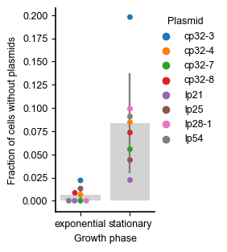

```python
_figsize = [3.4,3] # size of the figure in inches, w x h.

fig,_ax = plt.subplots(figsize=_figsize,layout='constrained')
sns.barplot(data=df,x='growth_phase',y='frac_no_plasmid',color = 'lightgray',errcolor='gray',ax=_ax,errwidth=1.7,errorbar='sd')
sns.swarmplot(data=df,x='growth_phase',y='frac_no_plasmid',hue='plasmid',ax=_ax,size=5,palette=sns.color_palette())
_ax.legend(frameon = False,bbox_to_anchor=(1.7,1),title='Plasmid',fontsize=9,title_fontsize=9)
_ax.tick_params(axis='both',labelsize=9)
_ax.spines[['right', 'top']].set_visible(False)
_ax.spines[['left', 'bottom']].set_linewidth(1.2)
_ax.set_ylabel('Fraction of cells without plasmids',fontsize=9)
_ax.set_xlabel('Growth phase',fontsize=9)
tstats = stats.ttest_ind(df[df.growth_phase == 'stationary'].plasmid_spots,df[df.growth_phase == 'exponential'].plasmid_spots,equal_var=False)
plt.savefig('plots/frac_no_plasmids.pdf',bbox_inches='tight')
print(f'p value is {tstats[1]}')
```

Finally, an interesting observation from looking at the per-plasmid variance between the biological replicates of the fraction of cells without plasmids suggests to me that the regulation of plasmid maintenance is affected in stationary phase. I will calculate the standard deviation for each plasmid and plot the pooled values.

```
p value is 0.055054928017876745
```

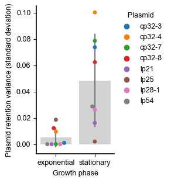

```python
_figsize = [3.5,3] # size of the figure in inches, w x h.

# Calculate the standard deviation of each replicate.
df=mean_df.groupby(by=['plasmid','growth_phase']).std().reset_index().drop(['num_no_plasmid','cell_num','replicate'],axis=1)
df.to_excel('std_dev_results.xlsx')

fig,_ax = plt.subplots(figsize=_figsize,layout='constrained')

sns.barplot(data=df,x='growth_phase',y='frac_no_plasmid',color = 'lightgray',errcolor='gray',ax=_ax,errwidth=1.7,errorbar='sd')
sns.swarmplot(data=df,x='growth_phase',y='frac_no_plasmid',hue='plasmid',ax=_ax,size=5,palette=sns.color_palette())
_ax.legend(frameon = False,bbox_to_anchor=(1.7,1),title='Plasmid',fontsize=9,title_fontsize=9)
_ax.tick_params(axis='both',labelsize=9)
_ax.set_ylabel('Plasmid retention variance (standard deviation)',fontsize=9)
_ax.set_xlabel('Growth phase',fontsize=9)
_ax.spines[['right', 'top']].set_visible(False)
_ax.spines[['left', 'bottom']].set_linewidth(1.2)
tstats = stats.ttest_ind(df[df.growth_phase == 'stationary'].plasmid_spots,df[df.growth_phase == 'exponential'].plasmid_spots,equal_var=False)
plt.savefig('plots/variance_per_plasmid.pdf',bbox_inches='tight')
print(f'p value is {tstats[1]}')
```

Just out of sheer curiosity, I plotted the observed plasmid spots vs. the fraction of cells without plasmids. There is an inverse correlation between the number of plasmid spots observed in a cell vs. the fraction of cells without plasmids. This makes sense though. If a condition has fewer plasmids to start, then of course they are more likely to be lost.

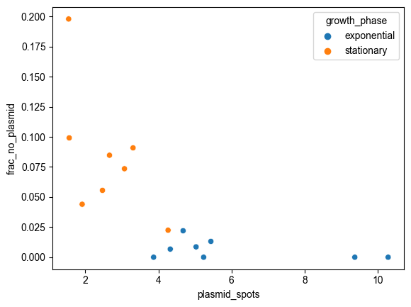

```python
df=mean_df.groupby(by=['plasmid','growth_phase']).mean().reset_index()
sns.scatterplot(data=df,x='plasmid_spots',y='frac_no_plasmid',hue='growth_phase')
```